https://www.datacamp.com/community/tutorials/markdown-in-jupyter-notebook https://jupyter-notebook.readthedocs.io/en/stable/examples/Notebook/Working%20With%20Markdown%20Cells.html

# Análise Exploratória dos Dados

Este script tem como objetivo explorar a base de dados:

- identificar os atributos disponíveis
- Tipos de dados
- Comportamento dos dados
- Valores nulos e/ou discrepantes (outlier)
- e fazer o tratamento dos dados necessário
1. Seleção dos Dados
2. Exploração dos Dados
3. Tratamento dos Dados
4. Análise Exploratória II
5. Conclusão
6. Próximas etapas

Este script seria utilizado apenas pela equipe técnica

```python
import pandas as pd
import numpy as np
import matplotlib.pyplot as plt
import seaborn as sns
from sklearn.preprocessing import LabelEncoder
```

```python
## função para calcular limite superior e inferior dos dados
def calc_limit_boxplot(data):
    q1 = data.quantile(.25)
    q3 = data.quantile(.75)

    sup = q3 + 1.5 * (q3-q1)
    inf = q1 - 1.5 * (q3-q1)

    return sup, inf
```

```python
cores_classe = [sns.color_palette("hls", 5)[0],sns.color_palette("hls", 5)[2]]
sns.set_palette(cores_classe)
```

## 1. Seleção dos dados

```python
dados = pd.read_csv('data/campaigns.csv')
```

- Identificando as atributos(nomes) e tipos de dados armazenados

```python
dados.info()
```

```
<class 'pandas.core.frame.DataFrame'>
RangeIndex: 40690 entries, 0 to 40689
Data columns (total 18 columns):
Unnamed: 0    40690 non-null int64
age           40690 non-null int64
job           40690 non-null object
marital       40690 non-null object
education     40690 non-null object
default       40690 non-null object
balance       40690 non-null int64
housing       40690 non-null object
loan          40690 non-null object
contact       40690 non-null object
day           40690 non-null int64
month         40690 non-null object
duration      40690 non-null int64
campaign      40690 non-null int64
pdays         40690 non-null int64
previous      40690 non-null int64
poutcome      40690 non-null object
y             40690 non-null object
dtypes: int64(8), object(10)
memory usage: 5.6+ MB
```

- É possível observar que há muitos atributos do tipo qualitativo
- É possível notar que não há nenhum valor faltante em nenhuma das colunas da base

Excluindo atributos irrelevante

```python
## excluindo colunas
dados.drop(columns=['Unnamed: 0'], inplace=True)
```

Estatística descritiva dos campos numéricos

```python
dados.describe()
```

|  | age | balance | day | duration | campaign | pdays | previous |
| --- | --- | --- | --- | --- | --- | --- | --- |
| count | 40690.000000 | 40690.000000 | 40690.000000 | 40690.000000 | 40690.000000 | 40690.000000 | 40690.000000 |
| mean | 40.905407 | 1359.697518 | 15.808405 | 258.243844 | 2.764586 | 40.059867 | 0.579405 |
| std | 10.604908 | 3034.248783 | 8.318281 | 257.577068 | 3.110158 | 100.078281 | 2.350664 |
| min | 18.000000 | -8019.000000 | 1.000000 | 0.000000 | 1.000000 | -1.000000 | 0.000000 |
| 25% | 33.000000 | 74.000000 | 8.000000 | 103.000000 | 1.000000 | -1.000000 | 0.000000 |
| 50% | 39.000000 | 451.000000 | 16.000000 | 180.000000 | 2.000000 | -1.000000 | 0.000000 |
| 75% | 48.000000 | 1423.000000 | 21.000000 | 319.000000 | 3.000000 | -1.000000 | 0.000000 |
| max | 95.000000 | 102127.000000 | 31.000000 | 4918.000000 | 63.000000 | 871.000000 | 275.000000 |

- podemos observar que os dados estão bem dispersos, não há uma distribuião padrão e estão com escalas bem distintas

## 2. Exploração dos Dados

A partir desta seção serão feitas algumas explorações da base de dados para saber como os dados se comportam, estão distribuídos dentre outras.

**Exploração das variáveis quantitativas**

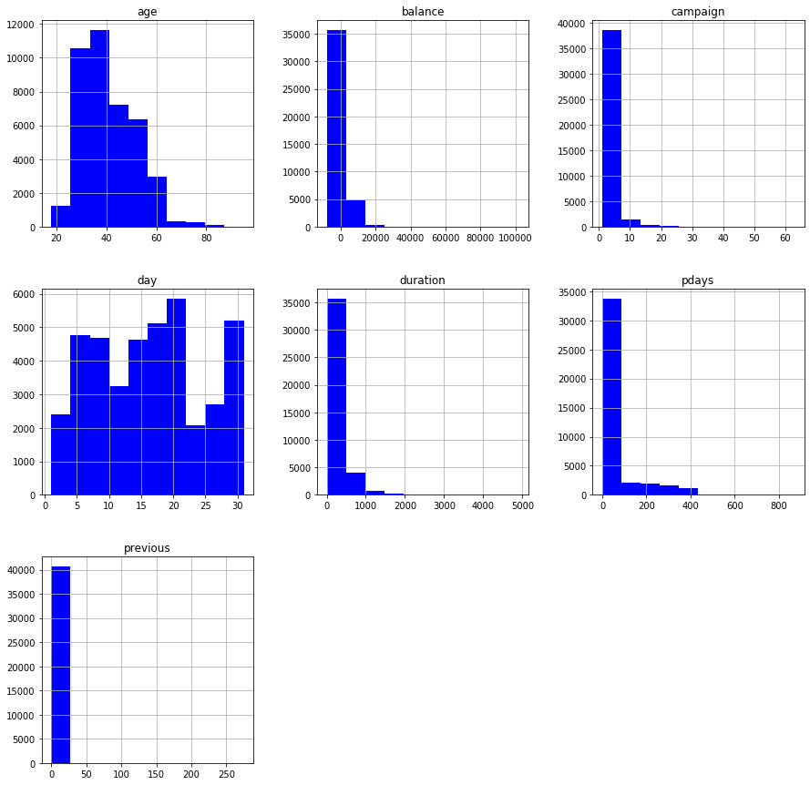

```python
dados.hist(figsize=(15,15), color = 'blue')
plt.show()
```

**Exploração das variáveis qualitativas**

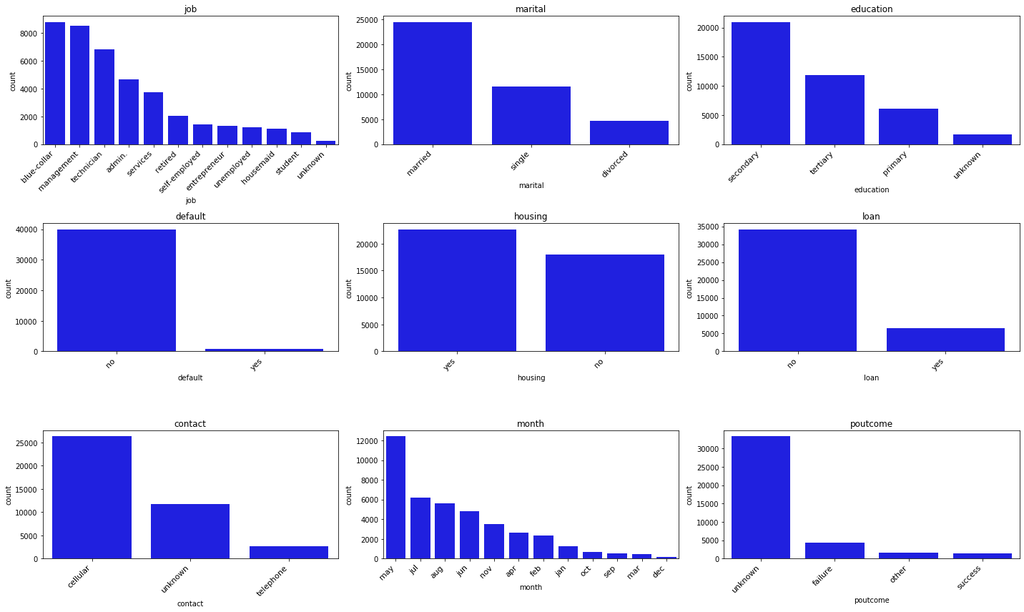

```python
c,r = 0,0
fig, axes = plt.subplots(3,3, figsize = (20,12))

for dtype in zip(dados.dtypes.index,dados.dtypes):

    if dtype[0] not in ['y'] and dtype[1] == object:
        #print(dtype[0], r,c)#print(dtype[0])
        #chart =
        #sns.distplot(d, kde=False, color="b", ax=axes[0, 0])
        order = dados[dtype[0]].value_counts().index

        #chart = sns.countplot(x = 'job', hue = 'y', data=dados_selec, order = order)
        chart = sns.countplot(x = dtype[0], data=dados, ax = axes[r,c], color = 'blue', order = order)
        chart.set_xticklabels(chart.get_xticklabels(), rotation=45, horizontalalignment='right', size = 11)
        #chart.set_yticklabels(chart.get_yticks(), size = 5)
        #plt.title('Frequência do atributo '+dtype[0])
        axes[r,c].set_title(dtype[0])
        fig.tight_layout()
        #sns.despine(left=True)
        if c == 2:
            r += 1
            c = 0
        else: c += 1


plt.show()
```

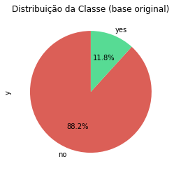

```python
qtd_y = dados['y'].value_counts()
qtd_y.plot.pie(title = 'Distribuição da Classe (base original)',
                      autopct='%.1f%%', startangle=90)

plt.show()
```

- É possível observar que há uma grande diferença entre as duas classes, isso pode ser um problema para o modelo de machine learning, mas será tratado mais a frente

### Conclusão Parcial

- Análise exploratória inicial foi apenas para conhecer a base de dados, identificar quais atributos e quais tipos de dados;
- também foi possível observar que alguns atributos tem comportamente bastante desbalanceado, por exemplo, `defaul`, `loan`. Porém, esse desbalanceamento não interfira nas análises.
- Por fim, identificamos que há um desbalanceamento considerável no atributo `y`. Este desbalanceamento pode interferir na elaboração do modelo para classificação. Mas será tratado mais a frente.

## 3. Tratamento dos Dados

Nessa seção serão realizadas algumas explorações mais afundo sobre os dados e alguns tratamentos (limpeza, transformação etc) dos dados.

Transformando o atributo `month` para quantitativo (Criando nova coluna de mês com dado quantitativo)

```python
## tratamento campo mês(para melhorar a visualizaão)
replace_month = {'jan':1,'feb':2,'mar':3,'apr':4,'may':5,'jun':6,'jul':7,'aug':8,'sep':9,'oct':10,'nov':11,'dec':12}
dados['month_new'] = dados.replace({'month':replace_month},inplace=False)['month']
```

convertendo variáveis qualitativas em quantitativas (Esse procedimento foi realizado para permitir fazer algumas análise estatísticas mais a frente)

```python
le = LabelEncoder()
for dtype in zip(dados.dtypes.index,dados.dtypes):
    if dtype[0] not in ['month'] and dtype[1] == object:
        print(dtype[0])
        dados[dtype[0]+'_new'] = le.fit_transform(dados[dtype[0]])
```

```
job
marital
education
default
housing
loan
contact
poutcome
y
```

```python
## verificando novas colunas criadas
dados.info()
```

```
<class 'pandas.core.frame.DataFrame'>
RangeIndex: 40690 entries, 0 to 40689
Data columns (total 27 columns):
age              40690 non-null int64
job              40690 non-null object
marital          40690 non-null object
education        40690 non-null object
default          40690 non-null object
balance          40690 non-null int64
housing          40690 non-null object
loan             40690 non-null object
contact          40690 non-null object
day              40690 non-null int64
month            40690 non-null object
duration         40690 non-null int64
campaign         40690 non-null int64
pdays            40690 non-null int64
previous         40690 non-null int64
poutcome         40690 non-null object
y                40690 non-null object
month_new        40690 non-null int64
job_new          40690 non-null int32
marital_new      40690 non-null int32
education_new    40690 non-null int32
default_new      40690 non-null int32
housing_new      40690 non-null int32
loan_new         40690 non-null int32
contact_new      40690 non-null int32
poutcome_new     40690 non-null int32
y_new            40690 non-null int32
dtypes: int32(9), int64(8), object(10)
memory usage: 7.0+ MB
```

```python
colunas_numericas = ['age','balance','campaign','day','duration','pdays','previous','y']
```

Análise do comportamento(distribuição) dos dados numéricos separados pela classe (Y)

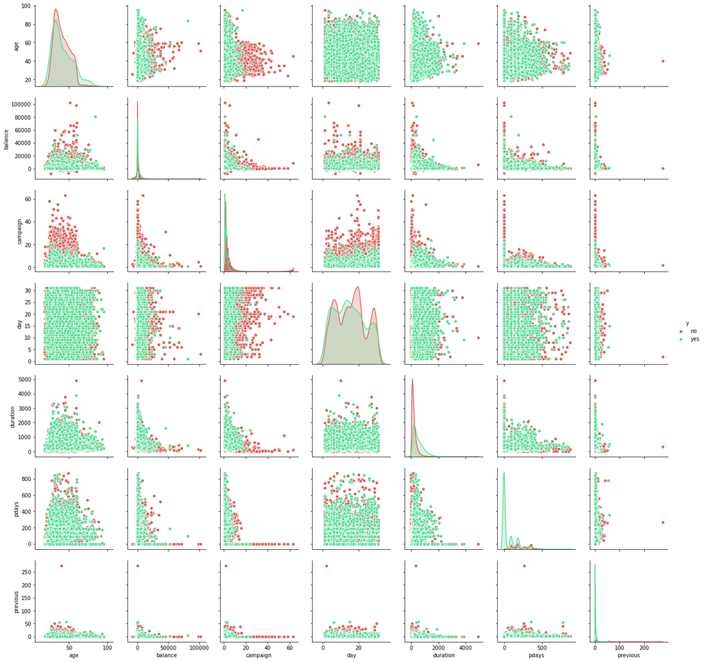

```python
plt.figure(figsize=(10,5))
sns.pairplot(dados[colunas_numericas], hue= 'y')
plt.show()
```

- Podemos observar que há nenhuma relação entre as variáveis
- É notado alguns que alguns atributos possuem outlier, como, `previus` e `campaign`

**Limpeza dos Outlier**

eliminando outlier da coluna `previous` e `campaign`, utilizando separatiz (quartil)

```python
print('base original: ', len(dados))
dados_clean = dados[dados.previous < dados.previous.quantile(.999)]
dados_clean = dados_clean[dados_clean.campaign < dados_clean.campaign.quantile(.99)]

print('base limpa: ', len(dados_clean))
```

```
base original:  40690
base limpa:  40234
```

Novo plot após eliminar outlier

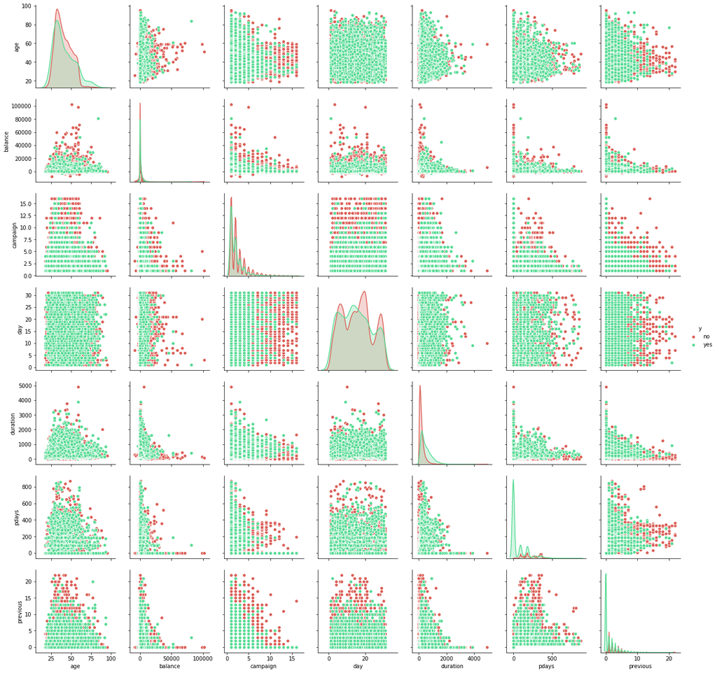

```python
plt.figure(figsize=(10,5))
sns.pairplot(dados_clean[colunas_numericas], hue= 'y')
plt.show()
```

- Após eliminar os outlier o comportamento dos dados melhorou um pouco mas ainda há alguns valores um tanto pouco discrepantes, por exemplo, em `duration`, `pdays`.

Analisando Dados com Boxplot

```python
## escala log para melhorar a visualização
dados_clean['balance_log'] = np.log(dados_clean.balance)
dados_clean['duration_log'] = np.log(dados_clean.duration)
```

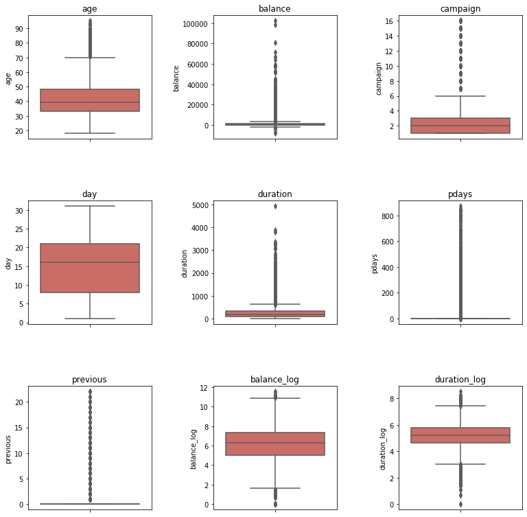

```python
from matplotlib.gridspec import GridSpec
gs = GridSpec(3,3,bottom=200,top=201,left=200,right=201,wspace=.5,hspace=.5) ## linas x colunas
plt.figure(figsize=(10,10))

for i, feature_name in enumerate(colunas_numericas[:-1] + ['balance_log','duration_log']):
    #print(i,feature_name)
    ax = plt.subplot(gs[i])
    #sns.boxplot(dados[feature_name], hue='y')
    sns.boxplot(y=feature_name, data=dados_clean)
    #plt.legend()
    ax.set_xlabel('')
    ax.set_title(str(feature_name))
```

- é possível identificar muitos outlier em quase todas as colunas
- podemos observar que a coluna `previous` e `pday` tem uma distribuião de valores muito ruim, mesmo eliminando os outliers anteriormente.

Remoção dos outlier

Nessa remoção dos oulier será utilizado o calculo do limite superior e inferior das coluna `age`,`campaign`,`balance`,`duration`.

```python
print('base original: ', len(dados))
dados_clean = dados_clean[dados_clean.age <= calc_limit_boxplot(dados_clean['age'])[0] ]

dados_clean = dados_clean[dados_clean.campaign <= calc_limit_boxplot(dados_clean['campaign'])[0] ]

dados_clean = dados_clean[(dados_clean.balance <= calc_limit_boxplot(dados_clean['balance'])[0]) &
                          (dados_clean.balance >= calc_limit_boxplot(dados_clean['balance'])[1])]

dados_clean = dados_clean[(dados_clean.duration <= calc_limit_boxplot(dados_clean['duration'])[0]) &
                         (dados_clean.duration >= calc_limit_boxplot(dados_clean['duration'])[1])]

print('base limpa: ', len(dados_clean))
```

```
base original:  40690
base limpa:  31140
```

Novo plot (boxplot) após eliminar outlier

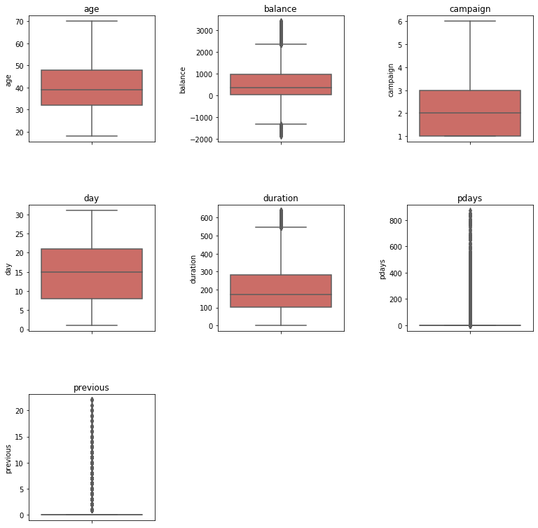

```python
from matplotlib.gridspec import GridSpec
gs = GridSpec(3,3,bottom=200,top=201,left=200,right=201,wspace=.5,hspace=.5) ## linas x colunas
plt.figure(figsize=(10,10))

for i, feature_name in enumerate(colunas_numericas[:-1]):
    #print(i,feature_name)
    ax = plt.subplot(gs[i])
    #sns.boxplot(dados[feature_name], hue='y')
    sns.boxplot(y=feature_name, data=dados_clean)
    #plt.legend()
    ax.set_xlabel('')
    ax.set_title(str(feature_name))
```

- conseguimos normalizar os dados, mas ainda há algumas colunas com muitos outliers
- mesmo com essa limpeza as colunas `pdays` e `previous` não alteraram nada, mais um indicativo que elas podem ser irrelevantes.
- esse procedimento diminuiu o tamanho da base de dados (por isso que a eliminação dos registros não é tão recomendado a ser feito de primeira)

Correção dos outlier

Como ainda há outlier algumas coluns, vamos tentar corrigir estes valores utilizando o valor do limite superior e inferior dos dados. (pode-se utilizar a média ou mediana, dependendo de como está a distribuição dos dados)

```python
for c in ['balance', 'duration']:
    print('{} - media: {:.2f} - mediana: {} - Limites: {}'.format(c, dados_clean[c].mean(), dados_clean[c].median(),
                                                                  calc_limit_boxplot(dados_clean[c])))
```

```
balance - media: 630.00 - mediana: 344.0 - Limites: (2346.0, -1334.0)
duration - media: 206.55 - mediana: 171.0 - Limites: (547.0, -165.0)
```

```python
## CORREÇÃO DE OUTLIER: age, balance, campaign, duration

## outlier superior
dados_clean['balance_new'] = np.where(dados_clean.balance >= calc_limit_boxplot(dados_clean['balance'])[0],
                                         calc_limit_boxplot(dados_clean['balance'])[0],
                                          #dados_clean.balance.median(),
                                         dados_clean.balance)
## outlier inferior
dados_clean['balance_new'] = np.where(dados_clean.balance <= calc_limit_boxplot(dados_clean['balance'])[1],
                                         calc_limit_boxplot(dados_clean['balance'])[1],
                                         #dados_clean.balance.median(),
                                      dados_clean.balance)

dados_clean['duration_new'] = np.where(dados_clean.duration >= calc_limit_boxplot(dados_clean['duration'])[0],
                                         calc_limit_boxplot(dados_clean['duration'])[0],
                                         dados_clean.duration)
```

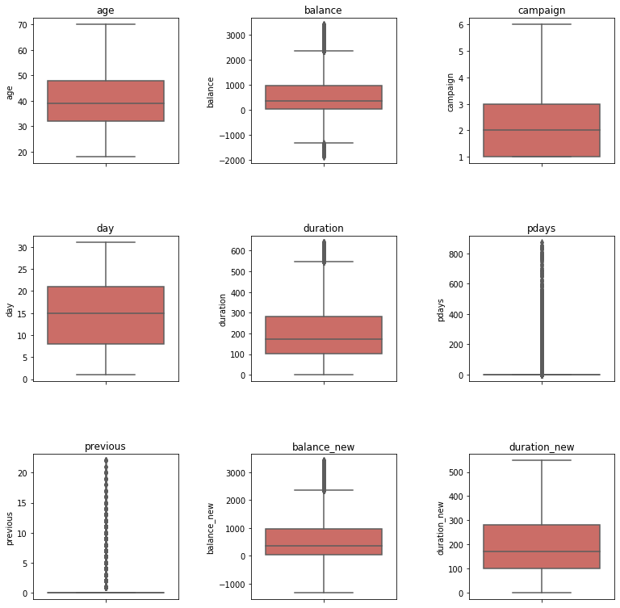

```python
from matplotlib.gridspec import GridSpec
gs = GridSpec(3,3,bottom=200,top=201,left=200,right=201,wspace=.5,hspace=.5) ## linas x colunas
plt.figure(figsize=(10,10))

for i, feature_name in enumerate(colunas_numericas[:-1] + ['balance_new','duration_new']):
    #print(i,feature_name)
    ax = plt.subplot(gs[i])
    #sns.boxplot(dados[feature_name], hue='y')
    sns.boxplot(y=feature_name, data=dados_clean)
    #plt.legend()
    ax.set_xlabel('')
    ax.set_title(str(feature_name))
```

- podemos observar que os valores discrepantes foram tratados, com execeção da coluna `balance`, que mesmo assim ainda continua com outlier mesmo após a correção.
- para este caso, deveríamos nos aprofundar nas análise estatística dessa coluna em específico.

```python
dados_clean.describe().round()
```

|  | age | balance | day | duration | campaign | pdays | previous | month_new | job_new | marital_new | ... | default_new | housing_new | loan_new | contact_new | poutcome_new | y_new | balance_log | duration_log | balance_new | duration_new |
| --- | --- | --- | --- | --- | --- | --- | --- | --- | --- | --- | --- | --- | --- | --- | --- | --- | --- | --- | --- | --- | --- |
| count | 31140.0 | 31140.0 | 31140.0 | 31140.0 | 31140.0 | 31140.0 | 31140.0 | 31140.0 | 31140.0 | 31140.0 | ... | 31140.0 | 31140.0 | 31140.0 | 31140.0 | 31140.0 | 31140.0 | 28245.0 | 31140.0 | 31140.0 | 31140.0 |
| mean | 40.0 | 630.0 | 15.0 | 207.0 | 2.0 | 42.0 | 1.0 | 6.0 | 4.0 | 1.0 | ... | 0.0 | 1.0 | 0.0 | 1.0 | 3.0 | 0.0 | -inf | -inf | 630.0 | 205.0 |
| std | 10.0 | 831.0 | 8.0 | 139.0 | 1.0 | 103.0 | 2.0 | 2.0 | 3.0 | 1.0 | ... | 0.0 | 0.0 | 0.0 | 1.0 | 1.0 | 0.0 | NaN | NaN | 830.0 | 135.0 |
| min | 18.0 | -1884.0 | 1.0 | 0.0 | 1.0 | -1.0 | 0.0 | 1.0 | 0.0 | 0.0 | ... | 0.0 | 0.0 | 0.0 | 0.0 | 0.0 | 0.0 | -inf | -inf | -1334.0 | 0.0 |
| 25% | 32.0 | 46.0 | 8.0 | 102.0 | 1.0 | -1.0 | 0.0 | 5.0 | 1.0 | 1.0 | ... | 0.0 | 0.0 | 0.0 | 0.0 | 3.0 | 0.0 | 5.0 | 5.0 | 46.0 | 102.0 |
| 50% | 39.0 | 344.0 | 15.0 | 171.0 | 2.0 | -1.0 | 0.0 | 6.0 | 4.0 | 1.0 | ... | 0.0 | 1.0 | 0.0 | 0.0 | 3.0 | 0.0 | 6.0 | 5.0 | 344.0 | 171.0 |
| 75% | 48.0 | 966.0 | 21.0 | 280.0 | 3.0 | -1.0 | 0.0 | 7.0 | 7.0 | 2.0 | ... | 0.0 | 1.0 | 0.0 | 2.0 | 3.0 | 0.0 | 7.0 | 6.0 | 966.0 | 280.0 |
| max | 70.0 | 3415.0 | 31.0 | 639.0 | 6.0 | 871.0 | 22.0 | 12.0 | 11.0 | 2.0 | ... | 1.0 | 1.0 | 1.0 | 2.0 | 3.0 | 1.0 | 8.0 | 6.0 | 3415.0 | 547.0 |

8 rows × 21 columns

## 4. Análise Explorátoria II

Nessa seção voltaremos a fazer uma nova análise exploratória dos dados:

- para cada classe(y)
- e verificar a correlação entre as colunas

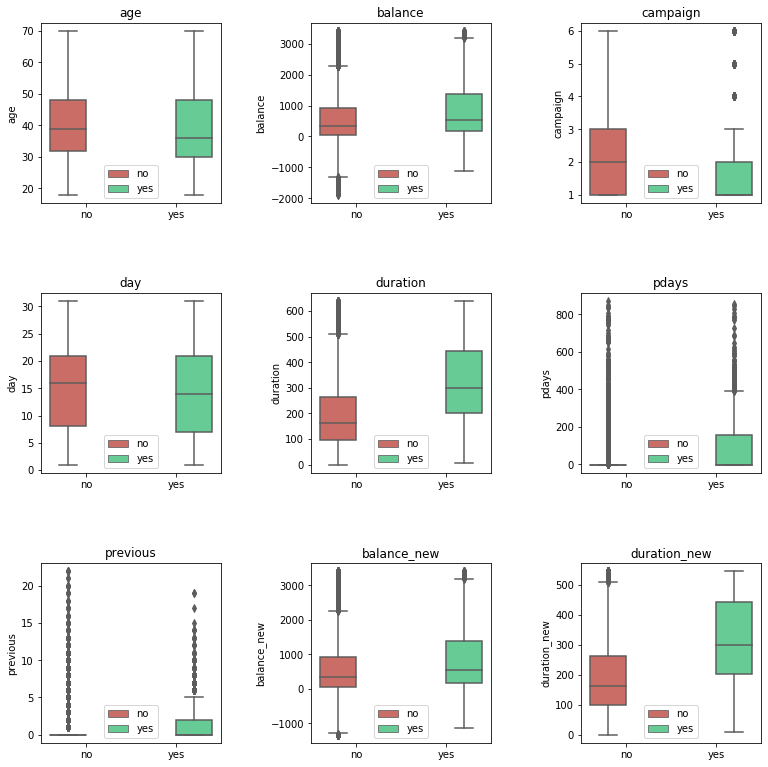

```python
from matplotlib.gridspec import GridSpec
gs = GridSpec(3,3,bottom=200,top=201,left=200,right=201,wspace=.5,hspace=.5) ## linas x colunas
plt.figure(figsize=(10,10))

for i, feature_name in enumerate(colunas_numericas[:-1] + ['balance_new','duration_new']):
    #print(i,feature_name)
    ax = plt.subplot(gs[i])
    sns.boxplot(x='y', y = feature_name, data=dados_clean, hue = 'y')
    plt.legend()
    ax.set_xlabel('')
    ax.set_title(str(feature_name))
```

Matriz de Correlação

Nessa seção será verificada a correlação das variáveis, utilizando o método de pearson.

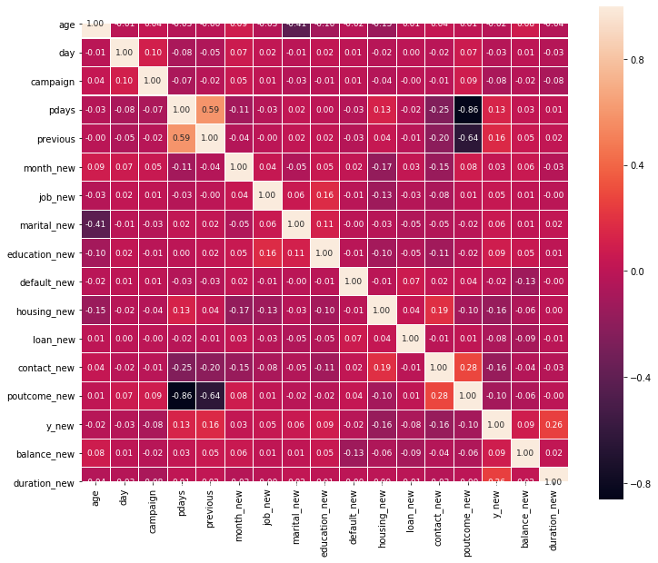

```python
plt.figure(figsize=(12,10))
chart = sns.heatmap(dados_clean.drop(columns=['balance','duration','balance_log','duration_log']).corr(),
                             linewidths=0.1, square=True, annot=True, fmt='.2f', annot_kws={"size": 9})

plt.show()
```

- podemos observar que há algumas correlações mais fortes mas negativas nas colunas `marital x age`,`poutcome x pdays`
- há algumas correlações positivas mas não tão fortes
- podemos observar que há uma certa correlação entra a variável `duration x y`. O que pode indicar que essa variável é determinante para indicar se o cliente vai aderir ou não ao produto.
- no mais, não há outras variáveis que faça correlação forte com a classe (Y)

```
Y original:
no     35903
yes     4787
Name: y, dtype: int64 -

Y limpa:
no     28546
yes     2594
Name: y, dtype: int64
```

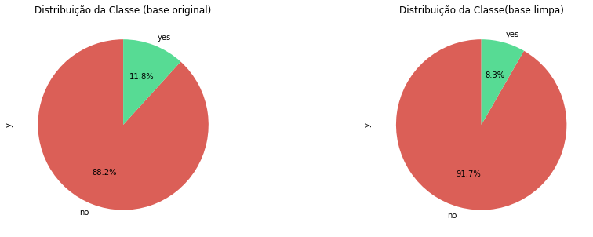

```python
qtd_y_original = dados['y'].value_counts()
qtd_y_limpo = dados_clean['y'].value_counts()

print('Y original: \n{} - \n\nY limpa: \n{}'.format(qtd_y_original, qtd_y_limpo))

fig, axs = plt.subplots(1,2, figsize = (15,5))
qtd_y_original.plot.pie(title = 'Distribuição da Classe (base original)',
                      autopct='%.1f%%', startangle=90, ax = axs[0])

qtd_y_limpo.plot.pie(title = 'Distribuição da Classe(base limpa)',
                      autopct='%1.1f%%', startangle=90, ax = axs[1])

plt.show()
```

## 4. Conclusão

- até o momento fizemos os seguintes procedimentos:
  - identificação do comportamento das variáveis numéricas, que há bastante ouliter
  - identificação dos valores para as variáveis categóricas, que há um certo desbalanceamento
  - tratamento dos dados, eliminando outlier
  - conversão das variáveis qualitativas em quantitativas
  - as colunas `balance` e `previous` tem um comportamento muito ruim, então, podem ser excluídas.
  - como identificado anteriormente, a nossa base teve uma diminuição de registros mas a classe que teve maior perda foi a `yes`, que é a nossa classe alvo positiva.
    - esse fator pode interferir no algoritmo de classificação.
    - caso seja necessário, voltaremos para a etapa de tratamento dos dados e ao invés de excluir os outlier, utilizar alguma métrica pra correção do mesmo.

```python
## SALVANDO DADOS TRATADOS EM UMA NOVA BASE
dados_clean.drop(columns=['balance','previous','balance_log','duration_log']).to_csv('data/dados_limpos.csv',index_label=False)
```

## 5. Próxima Etapas

- Realizar análise dos dados para extrair inforamções de negócio. [Análise de Dados](https://github.com/gabriellimagomes15/data-insight-assessment)
- Desenvolvimento de algoritmo de classificação. [Modelo ML classificação](https://github.com/gabriellimagomes15/data-insight-assessment)